# 1. Import Libraries

```python
import numpy as np
import matplotlib.pyplot as plt
import pandas as pd
import tensorflow as tf
import seaborn as sns
import os

from tensorflow.keras.layers import Dense, Conv2D, MaxPooling2D, Flatten, Dropout, BatchNormalization
from tensorflow.keras.models import Sequential
from tensorflow.keras.regularizers import l2
from tensorflow.keras.models import load_model
from tensorflow.keras.optimizers import SGD, Adam
from tensorflow.keras.preprocessing.image import ImageDataGenerator
from tensorflow.keras.utils import plot_model

from sklearn.utils.class_weight import compute_class_weight
from sklearn.preprocessing import LabelEncoder
from sklearn.metrics import classification_report
```

```python
# restrict tf from using all available memory on gpu
gpus = tf.config.experimental.list_physical_devices('GPU')
print(gpus)
for gpu in gpus:
	tf.config.experimental.set_memory_growth(gpu, True)
```

```python
# set random seed for reproducibility
np.random.seed(1)
```

# 2. Exploratory Data Analysis

```python
# change current working directory
dataset_path = r'D:\SP\Year 2 Sem 1\ST1504 Deep Learning\CA1\Part A\Dataset for CA1 part A - AY2425S1'
os.chdir(dataset_path)
```

Before I started loading the datasets, I went to see the images for each folder and realised that the images in the training beans folder had images of carrots (wrongly placed in the folder). I moved the images into a new folder called 'wrongly classified images' as they were already in the training carrots folder

There were also images with 'Copy' in their filename which I moved them into the wrongly classified images folder as well.

## A. File Analysis

```python
def list_file_extension(dataset):
    unique_file_extensions = []
    folders = os.listdir(dataset)  # list all the classes in the dataset

    for folder in folders:
        files = os.listdir(dataset + '/' + folder)  # list all the files in the class
        for file in files:
            _, file_extension = os.path.splitext(file)  # get the file extension name
            if file_extension not in unique_file_extensions:
                unique_file_extensions.append(file_extension)

    return unique_file_extensions
```

```python
# list out all the file extensions in each dataset
datasets = os.listdir()[:-1]
for dataset in datasets:
    print(f'{dataset}: {list_file_extension(dataset)}')
```

```
test: ['.jpg']
train: ['.jpg']
validation: ['.jpg']
```

Since the file extensions for all the images are in jpg, we do not need to worry about the file extensions

## B. Image Analysis

We need to rescale the image pixel values into [0-1] and converting the rgb images into greyscale

```python
def load_data_from_directory(train_dir, validation_dir, test_dir, img_size):
    """
    Loads data from each dataset directory and returns the data generators for the respective dataset
    """
    # rescale all the images to [0,1] in float format
    train_datagen = ImageDataGenerator(rescale=1./255)
    validation_datagen = ImageDataGenerator(rescale=1./255)
    test_datagen = ImageDataGenerator(rescale=1./255)

    print('Training Dataset')
    train_generator = train_datagen.flow_from_directory(
        train_dir,
        target_size=img_size,
        color_mode="grayscale",
        class_mode='categorical'
    )
    print()

    print('Validation Dataset')
    validation_generator = validation_datagen.flow_from_directory(
        validation_dir,
        target_size=img_size,
        color_mode="grayscale",
        class_mode='categorical'
    )
    print()

    print('Testing Dataset')
    test_generator = test_datagen.flow_from_directory(
        test_dir,
        target_size=img_size,
        color_mode="grayscale",
        class_mode='categorical'
    )
    print()

    return train_generator, test_generator, validation_generator
```

```python
train_folder = 'train'
validation_folder = 'validation'
test_folder = 'test'
```

```python
print('37px Dataset')
train_generator_37px, test_generator_37px, validation_generator_37px = load_data_from_directory(
    train_folder, test_folder, validation_folder, (37,37)
)
```

```
37px Dataset
Training Dataset
Found 9028 images belonging to 15 classes.

Validation Dataset
Found 3000 images belonging to 15 classes.

Testing Dataset
Found 3000 images belonging to 15 classes.
```

```python
print('131px Dataset')
train_generator_131px, test_generator_131px, validation_generator_131px = load_data_from_directory(
    train_folder, test_folder, validation_folder, (131,131)
)
```

```
131px Dataset
Training Dataset
Found 9028 images belonging to 15 classes.

Validation Dataset
Found 3000 images belonging to 15 classes.

Testing Dataset
Found 3000 images belonging to 15 classes.
```

Plot out first 4 images in the dataset to check whether it is greyscaled and in the correct resolution

```python
classes = np.array(os.listdir('train'))
```

```python
def implot(generator):
    """
    Plots the first 4 images from the generator
    """
    batch_images, batch_labels = next(generator)

    plt.figure(figsize=(12, 12))

    plt.subplot(221)
    plt.imshow(batch_images[0], cmap=plt.get_cmap('gray'))
    plt.title(f'{classes[np.where(batch_labels[0] == 1)[0][0]]}, {batch_images[0].shape}')  # display class name and image shape
    plt.axis('off')

    plt.subplot(222)
    plt.imshow(batch_images[1], cmap=plt.get_cmap('gray'))
    plt.title(f'{classes[np.where(batch_labels[1] == 1)[0][0]]}, {batch_images[1].shape}')  # display class name and image shape
    plt.axis('off')

    plt.subplot(223)
    plt.imshow(batch_images[2], cmap=plt.get_cmap('gray'))
    plt.title(f'{classes[np.where(batch_labels[2] == 1)[0][0]]}, {batch_images[2].shape}')  # display class name and image shape
    plt.axis('off')

    plt.subplot(224)
    plt.imshow(batch_images[3], cmap=plt.get_cmap('gray'))
    plt.title(f'{classes[np.where(batch_labels[3] == 1)[0][0]]}, {batch_images[3].shape}')  # display class name and image shape
    plt.axis('off')

    plt.show()
```

### i. 37px Dataset

Training Dataset

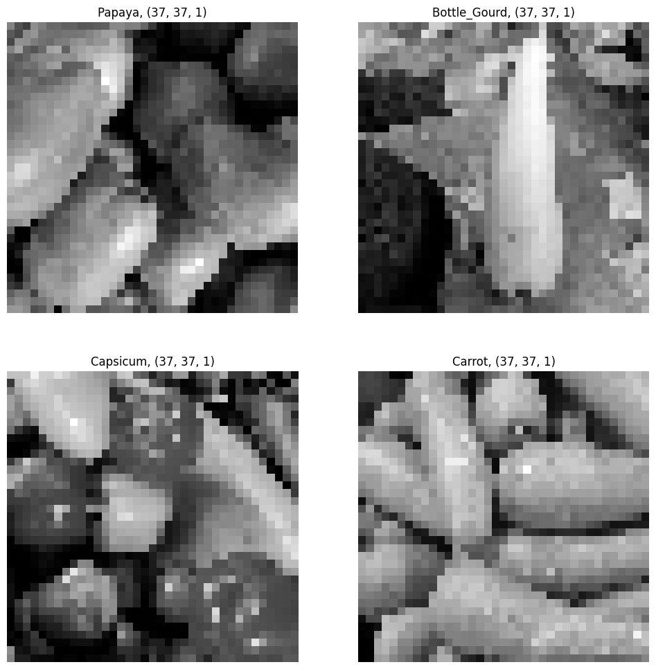

```python
implot(train_generator_37px)
```

Validation Dataset

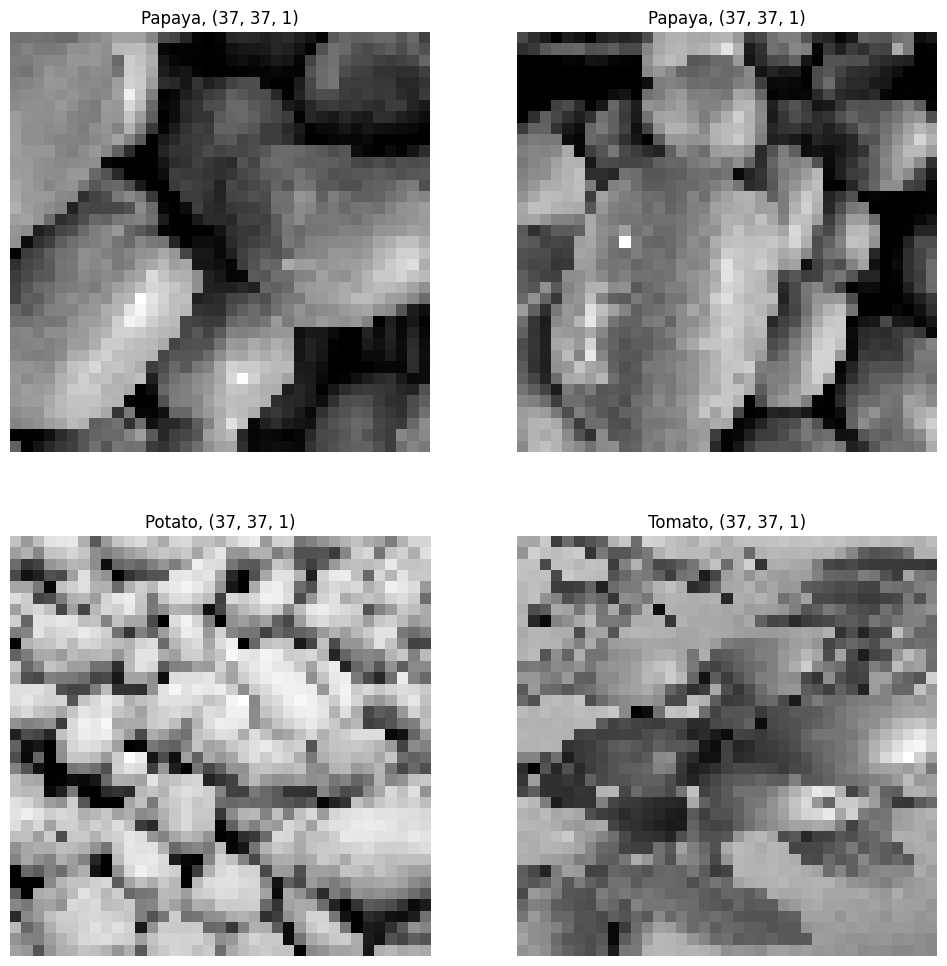

```python
implot(validation_generator_37px)
```

Testing Dataset

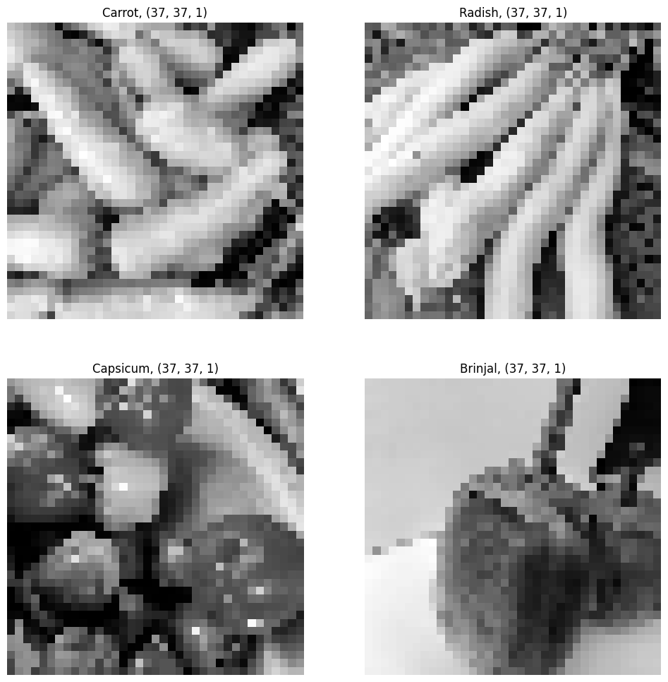

```python
implot(test_generator_37px)
```

### ii. 131px Dataset

Training Dataset

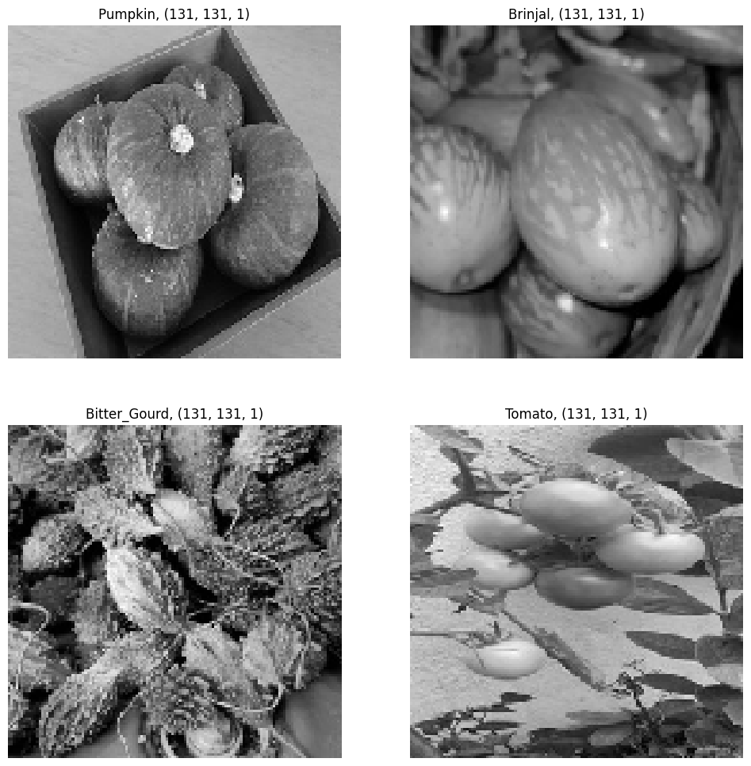

```python
implot(train_generator_131px)
```

Validation Dataset

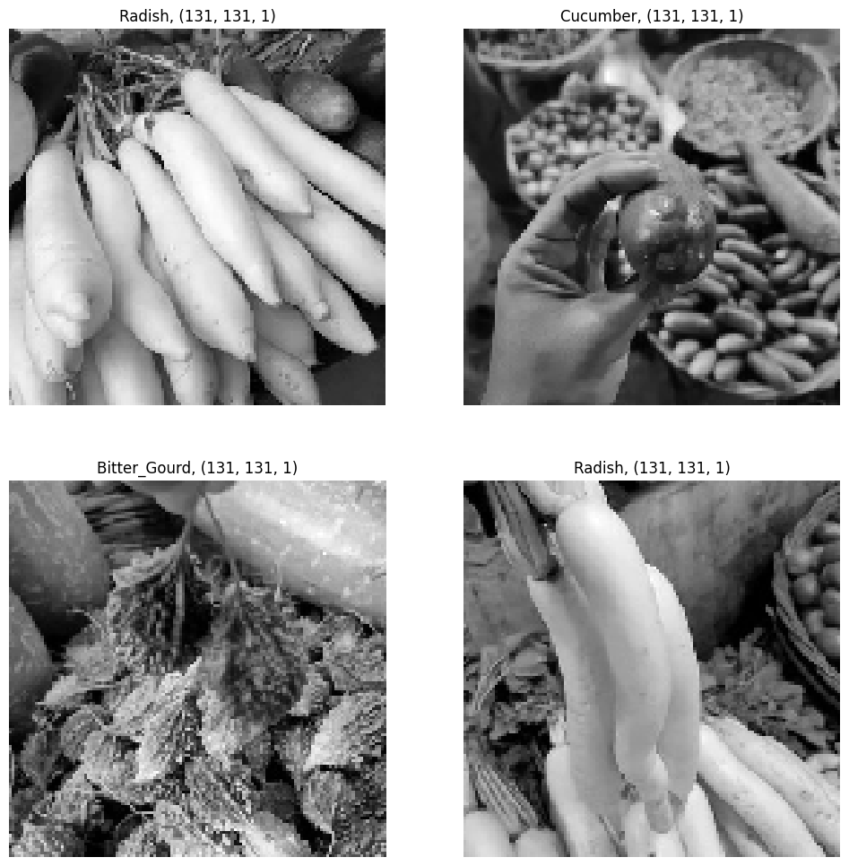

```python
implot(validation_generator_131px)
```

Testing Dataset

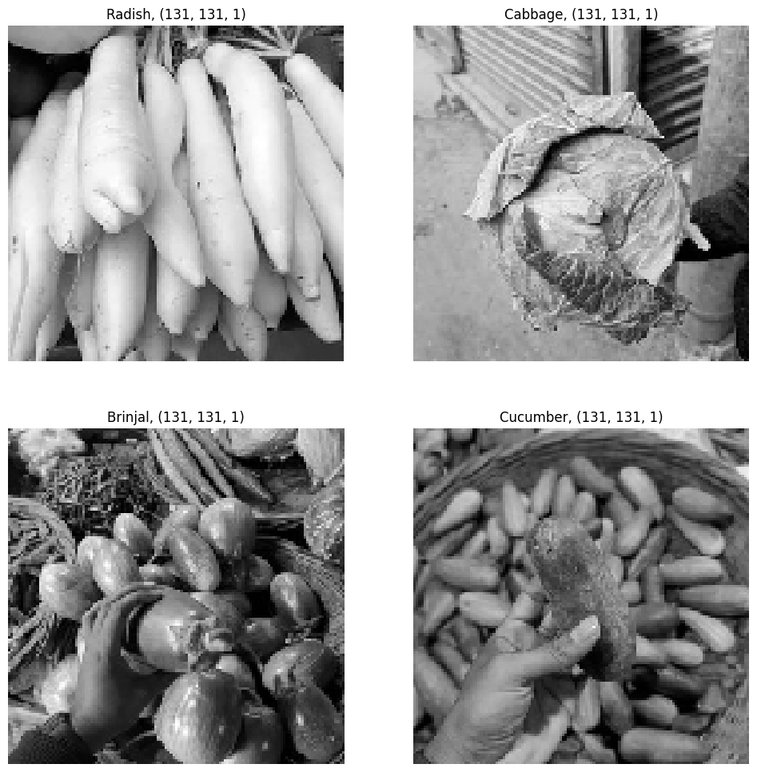

```python
implot(test_generator_131px)
```

## C. Class Analysis

View the different types of classes in the dataset

```python
for dataset in datasets:
    print(f'{dataset} Dataset')
    print(os.listdir(dataset))
    print()
```

```
test Dataset
['Bean', 'Bitter_Gourd', 'Bottle_Gourd', 'Brinjal', 'Broccoli', 'Cabbage', 'Capsicum', 'Carrot', 'Cauliflower', 'Cucumber', 'Papaya', 'Potato', 'Pumpkin', 'Radish', 'Tomato']

train Dataset
['Bean', 'Bitter_Gourd', 'Bottle_Gourd', 'Brinjal', 'Broccoli', 'Cabbage', 'Capsicum', 'Carrot', 'Cauliflower', 'Cucumber', 'Papaya', 'Potato', 'Pumpkin', 'Radish', 'Tomato']

validation Dataset
['Bean', 'Bitter_Gourd', 'Bottle_Gourd', 'Brinjal', 'Broccoli', 'Cabbage', 'Capsicum', 'Carrot', 'Cauliflower', 'Cucumber', 'Papaya', 'Potato', 'Pumpkin', 'Radish', 'Tomato']
```

View the distribution of images by class for training dataset

```python
def image_class_distribution():
    """
    Plot a bar graph to view the distribution of images per class
    """
    class_distribution = {
        'Class': classes,
        'Count': []
    }

    for i in range(len(classes)):
        class_distribution['Count'].append(len(os.listdir(os.path.join('train', classes[i]))))  # count number of images per class

    df = pd.DataFrame(class_distribution)

    sns.barplot(x='Class', y='Count', data=df)
    plt.xticks(rotation=90)
    plt.title('Image Class Distribution')
    plt.figure(figsize=(12,12))
    plt.show()
```

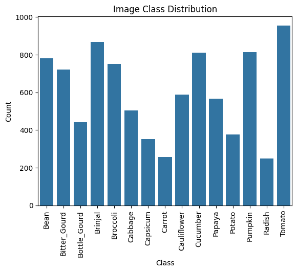

```python
image_class_distribution()
```

As shown in the bar chart, the distribution of images by class is not equal. We will need to consider this when we are training the model as the model may be biased towards the classes with more images. Hence. we will need to use class weights when training the model to give more weight to the classes with fewer images and less weight to the classes with more images

We will only apply this to training dataset as the validation and testing datasets are to test and evaluate the model's performance, not to train the model which won't lead to much biasness

```python
label_encoder = LabelEncoder()
classes_encoded = label_encoder.fit_transform(train_generator_37px.classes)  # one hot encode the class labels

class_weights = compute_class_weight('balanced', classes=np.unique(classes_encoded), y=classes_encoded)
class_weights_dict = dict(enumerate(class_weights))  # create a dictionary of class weights with respect to their class names

print(dict(zip(classes, class_weights)))
```

[output not shown]

# 3. Model Training

Define plot functions

```python
def plot_acc(hist):
    """
    Plot a line graph comparing the training and validation accuracy
    """
    plt.plot(hist.history['accuracy'])
    plt.plot(hist.history['val_accuracy'])
    plt.title('model accuracy')
    plt.ylabel('accuracy')
    plt.xlabel('epoch')
    plt.legend(['train', 'val'], loc='lower right')
    plt.show()
```

```python
def plot_loss(hist):
    """
    Plot a line graph comparing the training and validation loss
    """
    plt.plot(hist.history['loss'])
    plt.plot(hist.history['val_loss'])
    plt.title('model loss')
    plt.ylabel('loss')
    plt.xlabel('epoch')
    plt.legend(['train', 'val'], loc='upper left')
    plt.show()
```

## A. 37px Dataset

### i. Base Model

As this will be our first model, I will not make the model too complicated with too many layers

```python
model37px_1 = Sequential([
    Conv2D(32, (3,3), activation='relu', input_shape=(37,37,1)),
    MaxPooling2D((2,2)),

    Conv2D(64, (3,3), activation='relu'),
    MaxPooling2D((2,2)),

    Flatten(),

    Dense(128, activation='relu'),

    Dense(15, activation='softmax')
])

model37px_1.compile(loss='categorical_crossentropy', optimizer='adam', metrics=['accuracy'])

model37px_1.summary()
```

```
Model: "sequential"
_________________________________________________________________
 Layer (type)                Output Shape              Param #
=================================================================
 conv2d (Conv2D)             (None, 35, 35, 32)        320

 max_pooling2d (MaxPooling2D  (None, 17, 17, 32)       0
 )

 conv2d_1 (Conv2D)           (None, 15, 15, 64)        18496

 max_pooling2d_1 (MaxPooling  (None, 7, 7, 64)         0
 2D)

 flatten (Flatten)           (None, 3136)              0

 dense (Dense)               (None, 128)               401536

 dense_1 (Dense)             (None, 15)                1935

=================================================================
Total params: 422,287
Trainable params: 422,287
Non-trainable params: 0
_________________________________________________________________
```

```python
history1 = model37px_1.fit(
    train_generator_37px,
    batch_size=64,
    validation_data=validation_generator_37px,
    epochs=40,
    verbose=1,
    class_weight=class_weights_dict
)
```

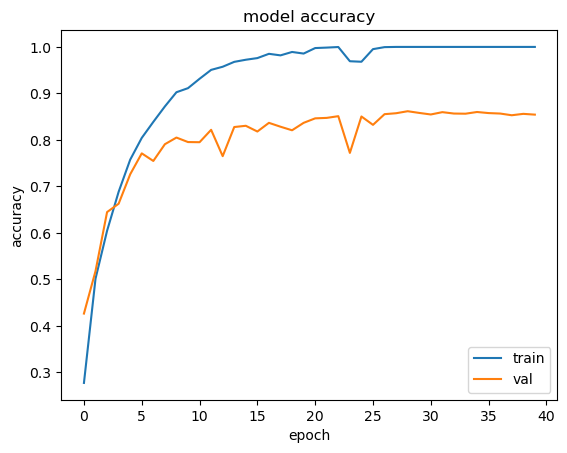

```python
plot_acc(history1)
```

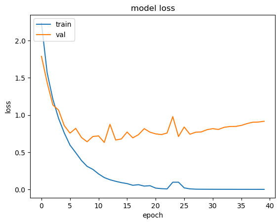

```python
plot_loss(history1)
```

### ii. Add More Layers

```python
model37px_2 = Sequential([
    Conv2D(32, (3,3), activation='relu', input_shape=(37,37,1)),
    BatchNormalization(),
    MaxPooling2D((2,2)),
    Dropout(0.2),

    Conv2D(64, (3,3), activation='relu'),
    BatchNormalization(),
    MaxPooling2D((2,2)),
    Dropout(0.2),

    Conv2D(64, (3,3), activation='relu'),
    BatchNormalization(),
    Dropout(0.2),

    Conv2D(64, (3,3), activation='relu'),
    BatchNormalization(),
    Dropout(0.2),

    Flatten(),

    Dense(128, activation='relu'),
    Dropout(0.2),

    Dense(15, activation='softmax')
])

model37px_2.compile(loss='categorical_crossentropy', optimizer=Adam(0.0001), metrics=['accuracy'])

model37px_2.summary()
```

```
Model: "sequential_1"
_________________________________________________________________
 Layer (type)                Output Shape              Param #
=================================================================
 conv2d_2 (Conv2D)           (None, 35, 35, 32)        320

 batch_normalization (BatchN  (None, 35, 35, 32)       128
 ormalization)

 max_pooling2d_2 (MaxPooling  (None, 17, 17, 32)       0
 2D)

 dropout (Dropout)           (None, 17, 17, 32)        0

 conv2d_3 (Conv2D)           (None, 15, 15, 64)        18496

 batch_normalization_1 (Batc  (None, 15, 15, 64)       256
 hNormalization)

 max_pooling2d_3 (MaxPooling  (None, 7, 7, 64)         0
 2D)

 dropout_1 (Dropout)         (None, 7, 7, 64)          0

 conv2d_4 (Conv2D)           (None, 5, 5, 64)          36928

 batch_normalization_2 (Batc  (None, 5, 5, 64)         256
 hNormalization)

 dropout_2 (Dropout)         (None, 5, 5, 64)          0

 conv2d_5 (Conv2D)           (None, 3, 3, 64)          36928

 batch_normalization_3 (Batc  (None, 3, 3, 64)         256
 hNormalization)

 dropout_3 (Dropout)         (None, 3, 3, 64)          0

 flatten_1 (Flatten)         (None, 576)               0

 dense_2 (Dense)             (None, 128)               73856

 dropout_4 (Dropout)         (None, 128)               0

 dense_3 (Dense)             (None, 15)                1935

=================================================================
Total params: 169,359
Trainable params: 168,911
Non-trainable params: 448
_________________________________________________________________
```

```python
history2 = model37px_2.fit(
    train_generator_37px,
    batch_size=64,
    validation_data=validation_generator_37px,
    epochs=125,
    verbose=1,
    class_weight=class_weights_dict
)
```

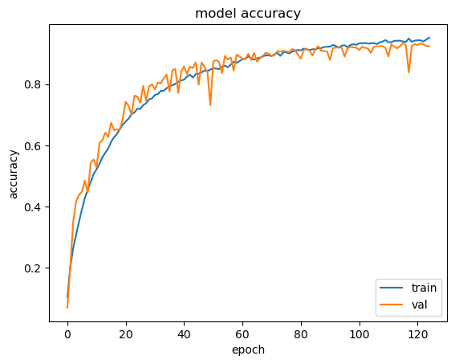

```python
plot_acc(history2)
```

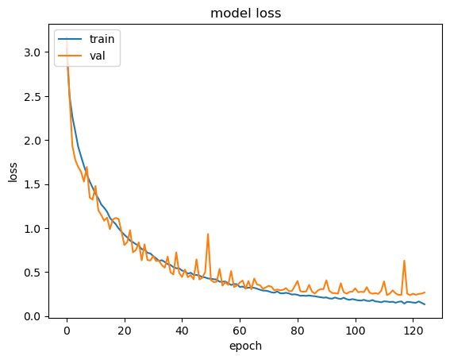

```python
plot_loss(history2)
```

The model's val accuracy is quite high and its val loss is quite low. There are no signs of over fitting too as the val and training metrics do not diverge and stay rather close to each other.

```python
os.chdir('../')  # go back 1 step up in the directory
```

```python
model37px_2.save(r'model37px_2.h5')
model37px_2.save_weights(r'model37px_2_weights.h5')
```

```python
os.chdir(dataset_path)
```

### iii. Adding L2 Regularization and Changing Optimizer & Learning Rate

```python
model37px_3 = Sequential([
    Conv2D(32, (3,3), activation='relu', input_shape=(37,37,1), kernel_regularizer=l2(0.0001)),
    BatchNormalization(),
    MaxPooling2D((2,2)),

    Conv2D(64, (3,3), activation='relu', kernel_regularizer=l2(0.0001)),
    BatchNormalization(),
    MaxPooling2D((2,2)),

    Conv2D(64, (3,3), activation='relu', kernel_regularizer=l2(0.0001)),
    BatchNormalization(),

    Conv2D(64, (3,3), activation='relu', kernel_regularizer=l2(0.0001)),
    BatchNormalization(),

    Flatten(),

    Dense(128, activation='relu', kernel_regularizer=l2(0.0001)),
    BatchNormalization(),

    Dense(15, activation='softmax')
])

model37px_3.compile(loss='categorical_crossentropy', optimizer=SGD(0.0005), metrics=['accuracy'])

model37px_3.summary()
```

```
Model: "sequential_2"
_________________________________________________________________
 Layer (type)                Output Shape              Param #
=================================================================
 conv2d_6 (Conv2D)           (None, 35, 35, 32)        320

 batch_normalization_4 (Batc  (None, 35, 35, 32)       128
 hNormalization)

 max_pooling2d_4 (MaxPooling  (None, 17, 17, 32)       0
 2D)

 conv2d_7 (Conv2D)           (None, 15, 15, 64)        18496

 batch_normalization_5 (Batc  (None, 15, 15, 64)       256
 hNormalization)

 max_pooling2d_5 (MaxPooling  (None, 7, 7, 64)         0
 2D)

 conv2d_8 (Conv2D)           (None, 5, 5, 64)          36928

 batch_normalization_6 (Batc  (None, 5, 5, 64)         256
 hNormalization)

 conv2d_9 (Conv2D)           (None, 3, 3, 64)          36928

 batch_normalization_7 (Batc  (None, 3, 3, 64)         256
 hNormalization)

 flatten_2 (Flatten)         (None, 576)               0

 dense_4 (Dense)             (None, 128)               73856

 batch_normalization_8 (Batc  (None, 128)              512
 hNormalization)

 dense_5 (Dense)             (None, 15)                1935

=================================================================
Total params: 169,871
Trainable params: 169,167
Non-trainable params: 704
_________________________________________________________________
```

```python
history3 = model37px_3.fit(
    train_generator_37px,
    batch_size=64,
    validation_data=validation_generator_37px,
    epochs=100,
    verbose=1,
    class_weight=class_weights_dict
)
```

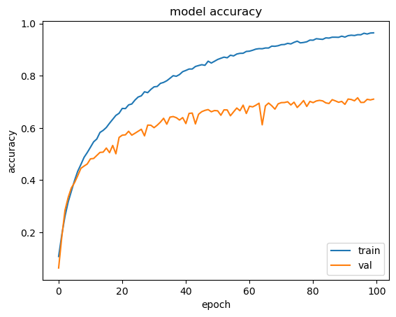

```python
plot_acc(history3)
```

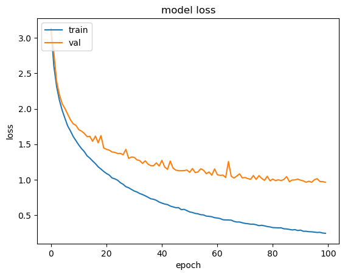

```python
plot_loss(history3)
```

## B. 131px Dataset

### i. Base Model

As this will be our first model, I will not make the model too complicated with too many layers

```python
model131px_1 = Sequential([
    Conv2D(64, (5,5), activation='relu', input_shape=(131,131,1)),
    MaxPooling2D((3,3)),

    Conv2D(96, (4,4), activation='relu'),
    MaxPooling2D((3,3)),

    Conv2D(96, (3,3), activation='relu'),
    MaxPooling2D((2,2)),

    Flatten(),

    Dense(256, activation='relu'),

    Dense(15, activation='softmax')
])

model131px_1.compile(loss='categorical_crossentropy', optimizer='adam', metrics=['accuracy'])

model131px_1.summary()
```

```
Model: "sequential_3"
_________________________________________________________________
 Layer (type)                Output Shape              Param #
=================================================================
 conv2d_10 (Conv2D)          (None, 127, 127, 64)      1664

 max_pooling2d_6 (MaxPooling  (None, 42, 42, 64)       0
 2D)

 conv2d_11 (Conv2D)          (None, 39, 39, 96)        98400

 max_pooling2d_7 (MaxPooling  (None, 13, 13, 96)       0
 2D)

 conv2d_12 (Conv2D)          (None, 11, 11, 96)        83040

 max_pooling2d_8 (MaxPooling  (None, 5, 5, 96)         0
 2D)

 flatten_3 (Flatten)         (None, 2400)              0

 dense_6 (Dense)             (None, 256)               614656

 dense_7 (Dense)             (None, 15)                3855

=================================================================
Total params: 801,615
Trainable params: 801,615
Non-trainable params: 0
_________________________________________________________________
```

```python
history4 = model131px_1.fit(
    train_generator_131px,
    batch_size=64,
    validation_data=validation_generator_131px,
    epochs=30,
    verbose=1,
    class_weight=class_weights_dict
)
```

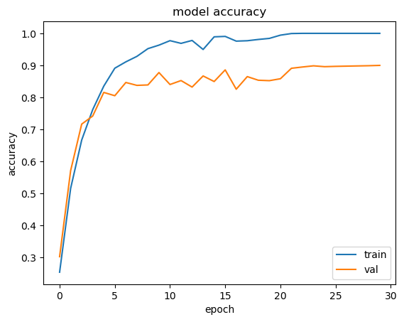

```python
plot_acc(history4)
```

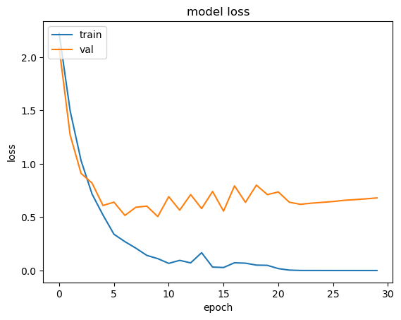

```python
plot_loss(history4)
```

Although the val accuracy is quite high (around 0.9), we will still try to add more layers to see if the model can perform better as the model is not too complex yet. Furthermore, the input size is bigger this time (131 x 131) and hence can afford to have more layers

### ii. Add More Layers

```python
model131px_2 = Sequential([
    Conv2D(64, (5,5), activation='relu', input_shape=(131,131,1)),
    BatchNormalization(),
    MaxPooling2D((3,3)),
    Dropout(0.2),

    Conv2D(96, (4,4), activation='relu'),
    BatchNormalization(),
    MaxPooling2D((3,3)),
    Dropout(0.2),

    Conv2D(96, (3,3), activation='relu'),
    BatchNormalization(),
    MaxPooling2D((2,2)),
    Dropout(0.2),

    Flatten(),

    Dense(256, activation='relu'),
    Dropout(0.2),

    Dense(15, activation='softmax')
])

model131px_2.compile(loss='categorical_crossentropy', optimizer='adam', metrics=['accuracy'])

model131px_2.summary()
```

```
Model: "sequential_4"
_________________________________________________________________
 Layer (type)                Output Shape              Param #
=================================================================
 conv2d_13 (Conv2D)          (None, 127, 127, 64)      1664

 batch_normalization_9 (Batc  (None, 127, 127, 64)     256
 hNormalization)

 max_pooling2d_9 (MaxPooling  (None, 42, 42, 64)       0
 2D)

 dropout_5 (Dropout)         (None, 42, 42, 64)        0

 conv2d_14 (Conv2D)          (None, 39, 39, 96)        98400

 batch_normalization_10 (Bat  (None, 39, 39, 96)       384
 chNormalization)

 max_pooling2d_10 (MaxPoolin  (None, 13, 13, 96)       0
 g2D)

 dropout_6 (Dropout)         (None, 13, 13, 96)        0

 conv2d_15 (Conv2D)          (None, 11, 11, 96)        83040

 batch_normalization_11 (Bat  (None, 11, 11, 96)       384
 chNormalization)

 max_pooling2d_11 (MaxPoolin  (None, 5, 5, 96)         0
 g2D)

 dropout_7 (Dropout)         (None, 5, 5, 96)          0

 flatten_4 (Flatten)         (None, 2400)              0

 dense_8 (Dense)             (None, 256)               614656

 dropout_8 (Dropout)         (None, 256)               0

 dense_9 (Dense)             (None, 15)                3855

=================================================================
Total params: 802,639
Trainable params: 802,127
Non-trainable params: 512
_________________________________________________________________
```

```python
history5 = model131px_2.fit(
    train_generator_131px,
    batch_size=64,
    validation_data=validation_generator_131px,
    epochs=35,
    verbose=1,
    class_weight=class_weights_dict
)
```

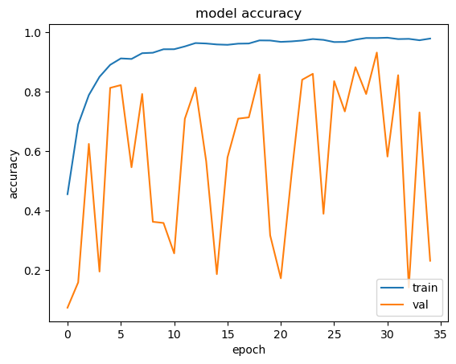

```python
plot_acc(history5)
```

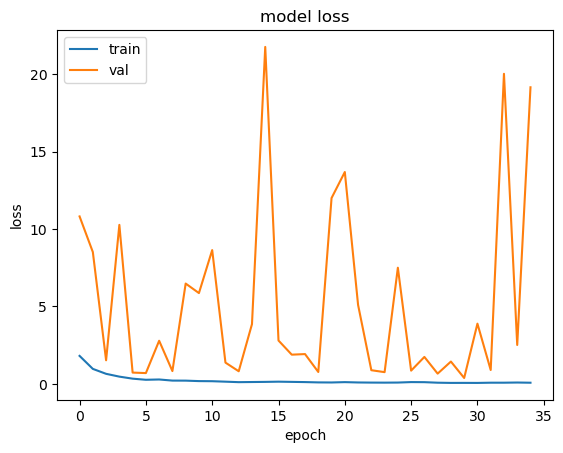

```python
plot_loss(history5)
```

From the graph, we can see that the model is very unstable as there are a lot of big jumps in the val metrics and the val loss is very high. We can lower the optimizer learning rate so that the model is not too unstable

### iii. Changing Optimizer Learning Rate

```python
model131px_3 = Sequential([
    Conv2D(64, (5,5), activation='relu', input_shape=(131,131,1)),
    BatchNormalization(),
    MaxPooling2D((3,3)),
    Dropout(0.2),

    Conv2D(96, (4,4), activation='relu'),
    BatchNormalization(),
    MaxPooling2D((3,3)),
    Dropout(0.2),

    Conv2D(96, (3,3), activation='relu'),
    BatchNormalization(),
    MaxPooling2D((2,2)),
    Dropout(0.2),

    Flatten(),

    Dense(256, activation='relu'),
    Dropout(0.2),

    Dense(15, activation='softmax')
])

model131px_3.compile(loss='categorical_crossentropy', optimizer=Adam(0.000025), metrics=['accuracy'])

model131px_3.summary()
```

```
Model: "sequential_5"
_________________________________________________________________
 Layer (type)                Output Shape              Param #
=================================================================
 conv2d_16 (Conv2D)          (None, 127, 127, 64)      1664

 batch_normalization_12 (Bat  (None, 127, 127, 64)     256
 chNormalization)

 max_pooling2d_12 (MaxPoolin  (None, 42, 42, 64)       0
 g2D)

 dropout_9 (Dropout)         (None, 42, 42, 64)        0

 conv2d_17 (Conv2D)          (None, 39, 39, 96)        98400

 batch_normalization_13 (Bat  (None, 39, 39, 96)       384
 chNormalization)

 max_pooling2d_13 (MaxPoolin  (None, 13, 13, 96)       0
 g2D)

 dropout_10 (Dropout)        (None, 13, 13, 96)        0

 conv2d_18 (Conv2D)          (None, 11, 11, 96)        83040

 batch_normalization_14 (Bat  (None, 11, 11, 96)       384
 chNormalization)

 max_pooling2d_14 (MaxPoolin  (None, 5, 5, 96)         0
 g2D)

 dropout_11 (Dropout)        (None, 5, 5, 96)          0

 flatten_5 (Flatten)         (None, 2400)              0

 dense_10 (Dense)            (None, 256)               614656

 dropout_12 (Dropout)        (None, 256)               0

 dense_11 (Dense)            (None, 15)                3855

=================================================================
Total params: 802,639
Trainable params: 802,127
Non-trainable params: 512
_________________________________________________________________
```

```python
history6 = model131px_3.fit(
    train_generator_131px,
    batch_size=64,
    validation_data=validation_generator_131px,
    epochs=120,
    verbose=1,
    class_weight=class_weights_dict
)
```

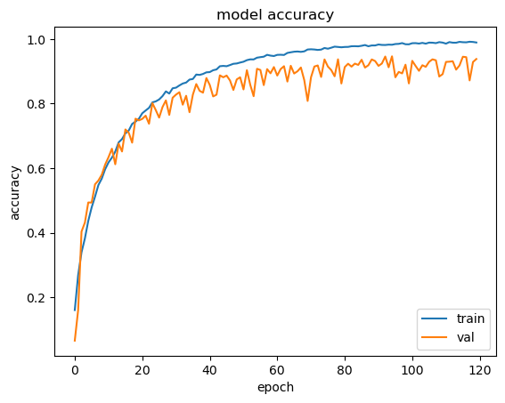

```python
plot_acc(history6)
```

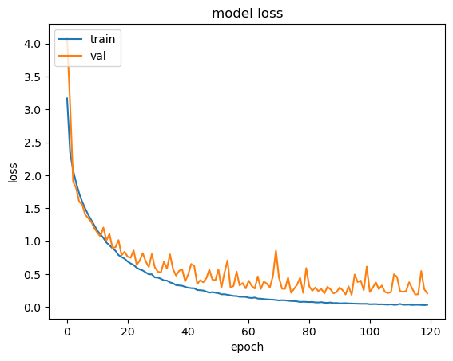

```python
plot_loss(history6)
```

Although there are still small fluctuations in the val metrics, the model is not as unstable as before. The val metrics are also better than the previous model. However, as the epochs increase, the val metrics slowly become more stable. There are no signs of overfitting too as the val metrics are not diverging away from the training metrics and remain relatively close to each other

```python
os.chdir('../')  # go back 1 step up in the directory
```

```python
model131px_3.save('model131px_3.h5')
model131px_3.save_weights('model131px_3_weights.h5')
```

# 4. Model Evaluation

We will determine which model to use by looking at the shape of the metrics (whether they show signs of overfitting or fluctuations), and the validation metrics

## A. 37px Dataset

Model 2 (Add More Layers) has the best validation metrics and the metrics are not diverging away from each other, showing that the model is not overfitting. Hence, we will use this model

```python
model37_px_loaded = load_model(r'model37px_2.h5')
```

```python
os.chdir(dataset_path)
```

```python
y37px_pred = model37_px_loaded.predict(test_generator_37px)
print(y37px_pred)
```

```
[[3.0948262e-04 9.0224314e-01 7.2796555e-09 ... 3.8502403e-04
  4.9772018e-07 9.6986851e-06]
 [1.4226084e-06 5.5877094e-06 5.1962343e-07 ... 7.8608571e-03
  1.5835209e-06 1.0755092e-05]
 [1.8152070e-08 1.9903825e-07 1.4530744e-06 ... 9.8961419e-01
  6.0049167e-11 2.3043440e-05]
 ...
 [9.7410685e-01 1.1539598e-02 1.7634957e-08 ... 4.0535303e-07
  1.1539761e-06 2.3687990e-06]
 [1.5147523e-06 1.5724846e-06 4.1363554e-10 ... 3.3053002e-04
  2.1011797e-09 1.0756351e-08]
 [5.2963856e-08 9.9994874e-01 1.8133380e-11 ... 3.1125084e-05
  4.3228242e-12 1.0648614e-09]]
```

```python
model37_px_loaded.evaluate(
    test_generator_37px,
    steps=test_generator_37px.samples // test_generator_37px.batch_size  # floor divide to get the number of steps
)
```

```
[0.2978675067424774, 0.9159946441650391]
```

### Visualise Model

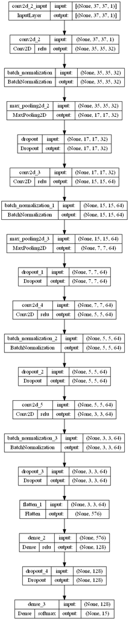

```python
plot_model(model37_px_loaded, show_shapes=True, expand_nested=True, show_layer_activations=True, show_layer_names=True, to_file="../model37px.png")
```

## B. 131px Dataset

Model 3 (Changing Optimizer Learning Rate) has the best validation metrics and the metrics are not diverging away from each other, showing that the model is not overfitting. Hence, we will use this model

```python
os.chdir('../')  # go back 1 step up in the directory
```

```python
model131_px_loaded = load_model(r'model131px_3.h5')
```

```python
os.chdir(dataset_path)
```

```python
y131px_pred = model131_px_loaded.predict(test_generator_131px)
print(y131px_pred)
```

```
[[5.7480793e-06 9.9775839e-01 4.4963203e-06 ... 1.3302429e-05
  3.1264615e-06 3.6022221e-10]
 [9.6779577e-06 3.6069166e-06 1.6904717e-11 ... 1.5861801e-06
  2.7269633e-09 9.9995077e-01]
 [4.1067267e-08 5.4257385e-09 1.4524801e-07 ... 2.5738634e-06
  1.0586767e-07 4.6447588e-09]
 ...
 [1.6099408e-07 6.0611043e-08 3.0000582e-02 ... 5.6398294e-05
  2.5560764e-06 1.5435553e-08]
 [1.5850464e-05 3.5613900e-06 1.0774281e-03 ... 5.1138189e-04
  9.9490708e-01 8.5730235e-06]
 [2.1977846e-09 2.9664189e-13 5.6794347e-09 ... 1.5215926e-06
  4.1085284e-11 8.7671015e-07]]
```

```python
model131_px_loaded.evaluate(
    test_generator_131px,
    steps=test_generator_131px.samples // test_generator_131px.batch_size  # floor divide to get the number of steps
)
```

```
[0.2233884632587433, 0.9368279576301575]
```

### Visualise Model

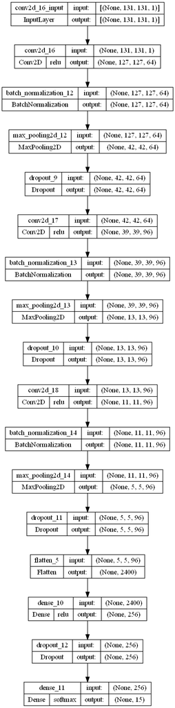

```python
plot_model(model131_px_loaded, show_shapes=True, expand_nested=True, show_layer_activations=True, show_layer_names=True, to_file="../model131.png")
```